# The Return of the Knowledge Scientist

An integrative curriculum to unlock the data-driven organization

Author

Daniel Kapitan, Joran Lokkerbol, George Fletcher, Paul Groth, Juan Sequeda

Published

September 1, 2022

## Introduction

In our appeal for the return of the Knowledge Scientist (Fletcher, Groth, and Sequeda (2020)) we have argued the need to improve reliance on data to unlock data-driven organization. In our view, to ‘rely on data’ can be unpacked into the following five properties:

Fletcher, George, Paul Groth, and Juan Sequeda. 2020. “Knowledge Scientists: Unlocking the Data-Driven Organization.” arXiv. https://doi.org/10.48550/arXiv.2004.07917.

1. Reliable data is clean data.
2. Reliable data is grounded in shared meaning spaces.
3. Reliable data is data in context. Clean data with shared meaning is not enough.
4. Reliable data is data accessible in a standardized format.
5. Reliable data is maintained.

We have argued that the lost art of knowledge identification, knowledge elicitation and knowledge specification needs to be reinstated in industry to complement current data science practices. We have called for a return of the knowledge scientist in organizations, development of new courses for educating knowledge scientists and research to study the tripartite relationship between data/knowledge models, their corresponding query languages and the people both using and producing reliable data.

In this paper, we outline an integrative curriculum for a post-graduate course on knowledge science, thereby rising to our own call. Given that a knowledge scientists needs a diverse set of skills, ranging from data engineering, knowledge acquisition, machine learning and human-computer interactions, we evaluate the different frameworks and concepts that are commonly used for teaching each of these discplines. We subsequently propose how these frameworks can conceptually integrated into a cohesive and logical curriculum. Finally, we discuss the feasibility of the proposed curriculum by reflecting on nascent knowledge science practice in Dutch government and healthcare organizations. These reflections are based on our experience with Professional Education at Jheronimus Academy of Data Science (JADS PE) and our work in advising organizations on unlocking the data-driven organization, particularly for government and healthcare.

## Overview of relevant frameworks

Our first challenge in defining a knowledge science curriculum is to arrive at a practical and meaningful scope of which existing domains and frameworks i.e. subjects are to be included. Table 1 lists the subjects and corresponding frameworks that we have included in our analysis.

Table 1: Domains and frameworks included in the analysis.

[output not shown]

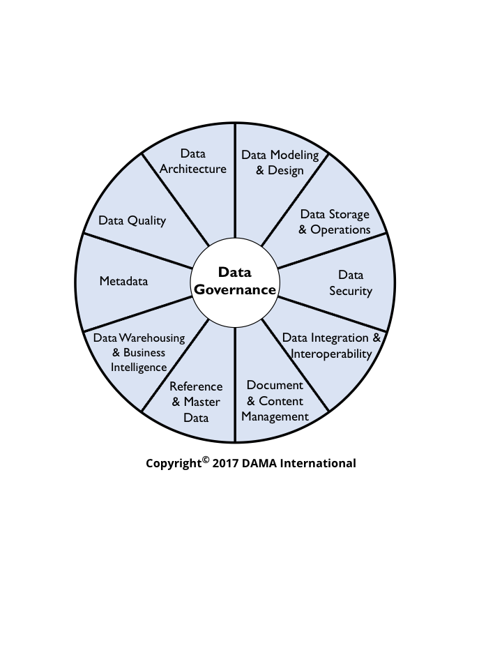

Figure 1: Wheel of the Data Management Body of Knowledge (DMBOK), second edition

## Current trends and challenges in data-drive innovation

“Data-Centric AI Resource Hub.” n.d. *Data-Centric AI Resource Hub*. https://datacentricai.org/.

- relates to linked data field of research
- recent advances to operationalize this via FAIR principles and relate to the [FAIR Digital Object Framework](https://fairdigitalobjectframework.org/)

How did we come to this, anyway?

- long-standing promises from linked data, knowledge engineering which didn’t quite pay-off yet, each with their own ‘winter’
- competing standards, no overarching end-to-end workflow yet. In theory UML2.0 open standaard, but transferring models between different UML tools is painful. Archimate is a better open standard, but less suitable for data modeling. Following MIM we want to include attributes in conceptual data model. From another perspective, linked data formats (RDF, Turtles) are expressive in capturing semantic and conceptual levels, but still a gap to translate that in the toolchain
- Historically, datawarehousing has been dominated by the dimensional modeling pattern by Kimball. Although concept of data vault has been around for a while, this approach is difficult to implement. Very labour intensive, new generation of code generation tools. But still now integrated workflow to go from semnatic –> conceptual –> logical –> physical

## The return of the knowledge scientist: a revised curriculum

### Elements of curriculum

- Methods for semantic knowledge engineering: CommonKADS, Cogniam, PROTEGE
- Methods for conceptual knowledge engineering:
  - Linked Data, UML2.0 …
  - FDOF, …
- Methods for logical layer:
  - Data vault
  - Graph databases: SPARQL, new GQL standard